# asvab_work

Tiasia Saunders

2025-04-25

### ASVAB Test Demographics Analysis

##### The ASVAB test is a standardized test used by the U.S. military to assess the skills and abilities of potential recruits. It covers a range of subjects, including mathematics, verbal skills, and technical knowledge. The test is designed to help determine an individual’s suitability for various military occupations.

##### This analysis will focus on the race, age, and gender demographics of the ASVAB applicants. Additonally, this analyis will focus on the U.S. Air Force Eligility by race focused on the four composite scores: General, Mechanical, Administrative, and Electronics.

```r
# load libraries
library(tidyverse)
library(readxl)
library(rio)
library(janitor)
```

```r
library(ggplot2)
library(scales)
# loading data
asvab_data <- read_excel("asvab_data_2020-2024.xlsx")
```

```r
# clean heading names
asvab_data <- asvab_data|>
  clean_names()
```

```r
# clean data
asvab_clean <- asvab_data %>%
  filter(if_any(everything(), ~ !is.na(.))) %>%
  mutate(across(where(is.character), str_trim)) %>%
  mutate(across(where(is.character), ~ na_if(., ""))) %>%
  mutate(across(where(is.character), ~ na_if(., "N/A"))) %>%
  mutate(across(where(is.character), ~ na_if(., "Unknown")))
```

## Summarizing the data

### Race distribution

```r
race_counts <- asvab_clean |>
  separate_rows(race, sep = ",\\s*") |>   # splits by comma and optional space
  count(race, sort = TRUE)

print(race_counts)
```

```
## # A tibble: 8 × 2
##   race                                           n
##   <chr>                                      <int>
## 1 White                                     197129
## 2 <NA>                                      186121
## 3 Black or African American                  95875
## 4 Asian                                      25544
## 5 Native Hawaiian or Other Pacific Islander   8517
## 6 American Indian/Alaska Native               8097
## 7 Identification Pending                       999
## 8 Declined to Respond                           28
```

### Gender distribution

```r
gender_count <- asvab_clean |>
  count(sex, sort = TRUE) |>
  print()
```

```
## # A tibble: 3 × 2
##   sex         n
##   <chr>   <int>
## 1 Male   332846
## 2 Female 156518
## 3 <NA>    11988
```

### Graphic of gender distribution

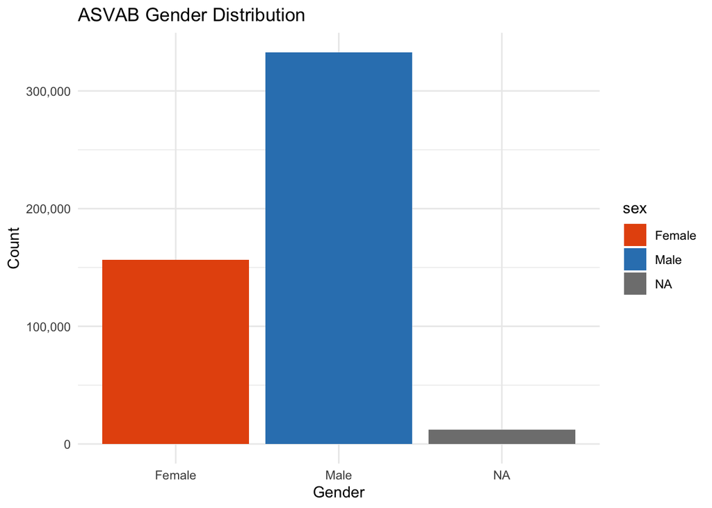

```r
ggplot(gender_count, aes(x = sex, y = n, fill = sex)) +
  geom_col() +
  scale_fill_manual(values = c("Male" = "#3182bd", "Female" = "#e6550d")) +
  scale_y_continuous(labels = scales::label_comma()) +
  labs(title = "ASVAB Gender Distribution",
       x = "Gender",
       y = "Count") +
  theme_minimal()
```